# What kind of storm is the most harmful respect to popluation health and economic health?

Synopsis: Based on the NOAA Storm Data, the analysis concludes that TORNADO is the most harmful event respect to population health and economic consequences among all the storm types.

## Introduction

Storms and other severe weather events can cause both public health and economic problems for communities and municipalities. Many severe events can result in fatalities, injuries, and property damage, and preventing such outcomes to the extent possible is a key concern.

This project involves exploring the U.S. National Oceanic and Atmospheric Administration’s (NOAA) storm database. This database tracks characteristics of major storms and weather events in the United States, including when and where they occur, as well as estimates of any fatalities, injuries, and property damage.

## Data Processing

The data comes from the National Weather Service [Storm Data Center](https://d396qusza40orc.cloudfront.net/repdata%2Fpeer2_doc%2Fpd01016005curr.pdf) with comma-seperation.

```r
library(dplyr)
storm <- read.csv("repdata-data-StormData.csv", header=TRUE, sep=",")
head(storm,3)
```

```
##   STATE__          BGN_DATE BGN_TIME TIME_ZONE COUNTY COUNTYNAME STATE
## 1       1 4/18/1950 0:00:00     0130       CST     97     MOBILE    AL
## 2       1 4/18/1950 0:00:00     0145       CST      3    BALDWIN    AL
## 3       1 2/20/1951 0:00:00     1600       CST     57    FAYETTE    AL
##    EVTYPE BGN_RANGE BGN_AZI BGN_LOCATI END_DATE END_TIME COUNTY_END
## 1 TORNADO         0                                               0
## 2 TORNADO         0                                               0
## 3 TORNADO         0                                               0
##   COUNTYENDN END_RANGE END_AZI END_LOCATI LENGTH WIDTH F MAG FATALITIES
## 1         NA         0                      14.0   100 3   0          0
## 2         NA         0                       2.0   150 2   0          0
## 3         NA         0                       0.1   123 2   0          0
##   INJURIES PROPDMG PROPDMGEXP CROPDMG CROPDMGEXP WFO STATEOFFIC ZONENAMES
## 1       15    25.0          K       0
## 2        0     2.5          K       0
## 3        2    25.0          K       0
##   LATITUDE LONGITUDE LATITUDE_E LONGITUDE_ REMARKS REFNUM
## 1     3040      8812       3051       8806              1
## 2     3042      8755          0          0              2
## 3     3340      8742          0          0              3
```

For our questions, we only focus on several variables:

```r
storm <- select(storm, EVTYPE, FATALITIES, INJURIES, PROPDMG, CROPDMG)
head(storm,3)
```

```
##    EVTYPE FATALITIES INJURIES PROPDMG CROPDMG
## 1 TORNADO          0       15    25.0       0
## 2 TORNADO          0        0     2.5       0
## 3 TORNADO          0        2    25.0       0
```

## Results

### Across the United States, which types of events are most harmful with respect to population health?

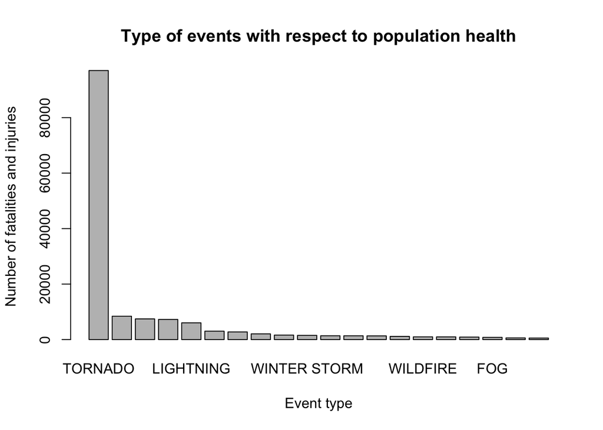

```r
population <- mutate(storm, p_health=FATALITIES+INJURIES)
by_type <- aggregate(p_health~EVTYPE, data=population, sum)
by_type <- arrange(by_type, desc(p_health))
barplot( height=by_type$p_health[1:20],names.arg=by_type$EVTYPE[1:20], xlab="Event type",
     ylab="Number of fatalities and injuries",
     main="Type of events with respect to population health")
```

As we can see from the results, TORNADO is most harmful with respect to population health.

### Across the United States, which types of events have the greatest economic consequences?

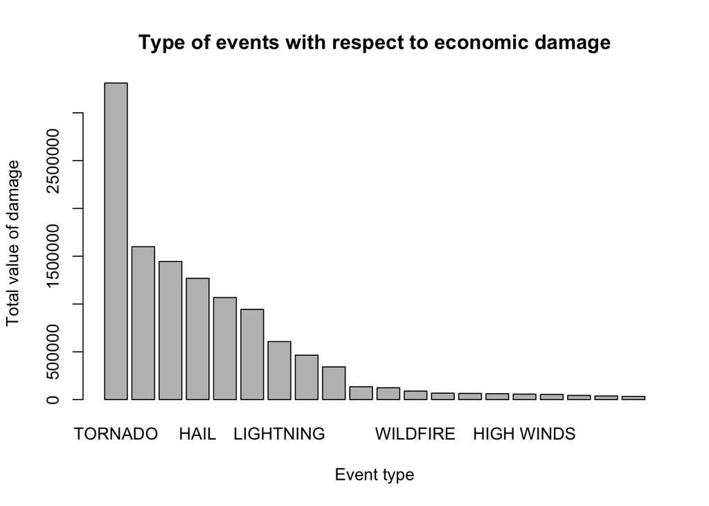

```r
economic <- mutate(storm, eco_con=PROPDMG+CROPDMG)
eco_type <- aggregate(eco_con~EVTYPE, data=economic, sum)
eco_type <- arrange(eco_type, desc(eco_con))
barplot( height=eco_type$eco_con[1:20],names.arg=eco_type$EVTYPE[1:20], xlab="Event type",
     ylab="Total value of damage",
     main="Type of events with respect to economic damage")
```

As we can see from the results, TORNADO has the greatest economic consequencces.

## Summary

For the above analysis, we can see TORNADO is the most damagable event respect to population health and economic consequences.